# Appli1 : Cartographie des flux

Author

Grasland C.

## Benin 2013 / Dept

On utilise les données IPUMS du recensement de 2013. On s’intéresse aux migrations durée de vie (entre le lieu de naissance et le lieu de résidence).

## Fonds de carte

On utilise le découpage de premier niveau du pays.

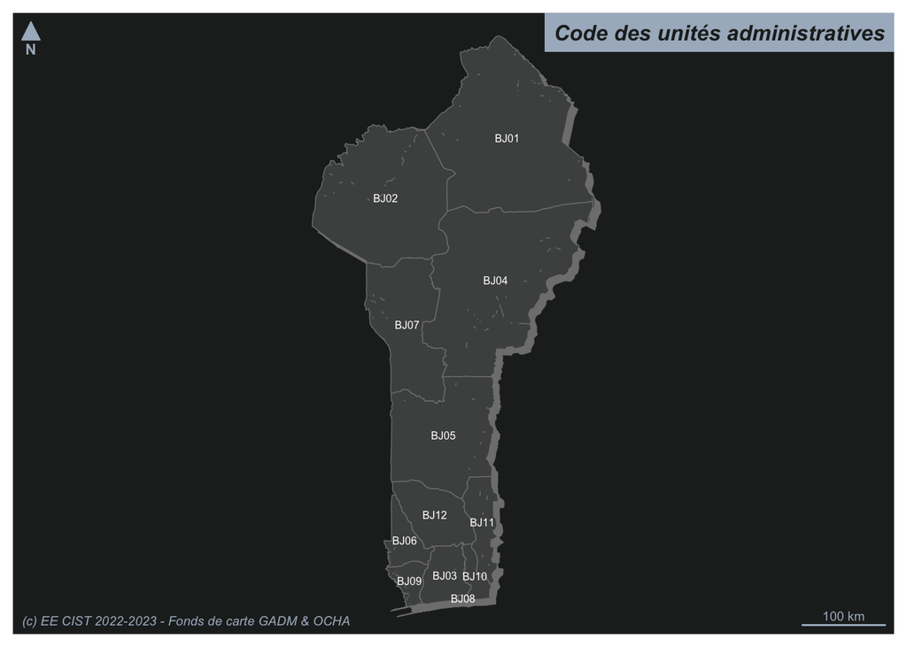

## Matrice de migration totale

On extrait la matrice de migration totale puis on calcule pour chaque paire de régions le solde et le volume des échanges.

```
# A tibble: 6 × 12
# Groups:   i [1]
  i     j     Ni      Nj      Fij   Fji  FVij   FSij     Xi     Yi     Xj     Yj
  <chr> <chr> <chr>   <chr> <dbl> <dbl> <dbl>  <dbl>  <dbl>  <dbl>  <dbl>  <dbl>
1 BJ01  BJ02  Alibori Atak…  4720  2180  6900  -2540 3.23e5 1.27e6 1.75e5 1.20e6
2 BJ01  BJ03  Alibori Atla…  2940   500  3440  -2440 3.23e5 1.27e6 2.47e5 7.38e5
3 BJ01  BJ04  Alibori Borg… 17040  5460 22500 -11580 3.23e5 1.27e6 3.09e5 1.10e6
4 BJ01  BJ05  Alibori Coll…  1950  2770  4720    820 3.23e5 1.27e6 2.45e5 9.09e5
5 BJ01  BJ06  Alibori Kouf…   100   320   420    220 3.23e5 1.27e6 1.98e5 7.81e5
6 BJ01  BJ07  Alibori Donga  1150  1910  3060    760 3.23e5 1.27e6 2.01e5 1.04e6
```

### Volume

On représente les volumes de flux dont la valeur est supérieure à la moyenne .

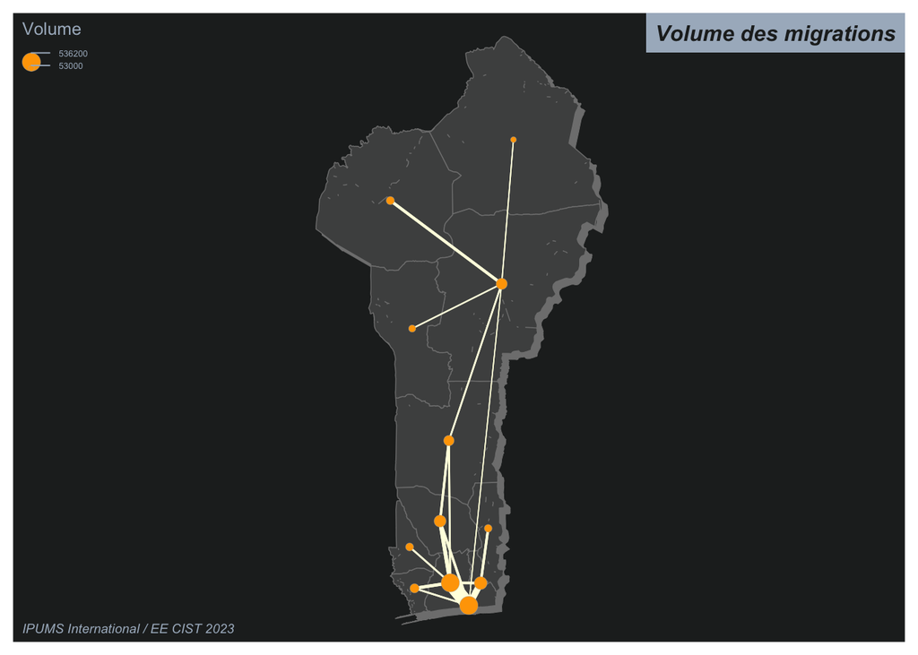

### Solde

On représente les soldes de flux dont la valeur est supérieure à la moyenne .

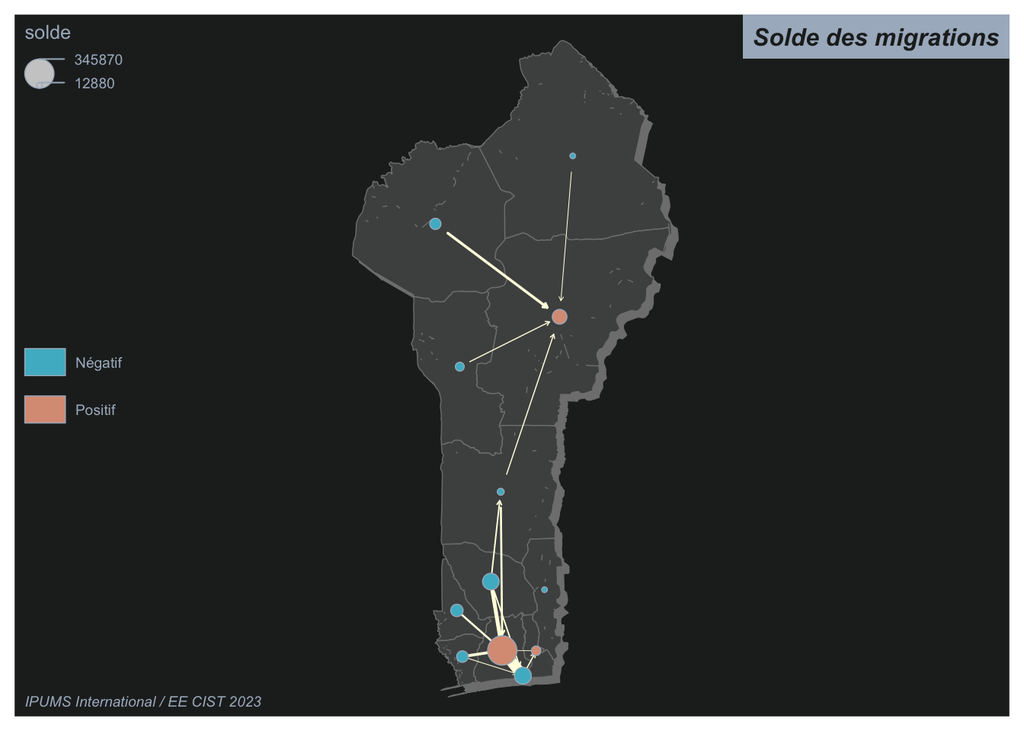

### Flux dominant

On détermine pour chaque unité spatiale son flux le plus important vers une autre unité spatiale. On considère qu’une unité est de type :

- **dominante** si son nombre si son nombre d’arrivée est supérieur à l’unité vers laquelle elle envoie son plus grand flux.
- **dominée** si son nombre d’arrivée est inférieur à l’unité vers laquelle elle envoie son plus grand flux.
- **relais** si elle est à la fois dominée et dominante.

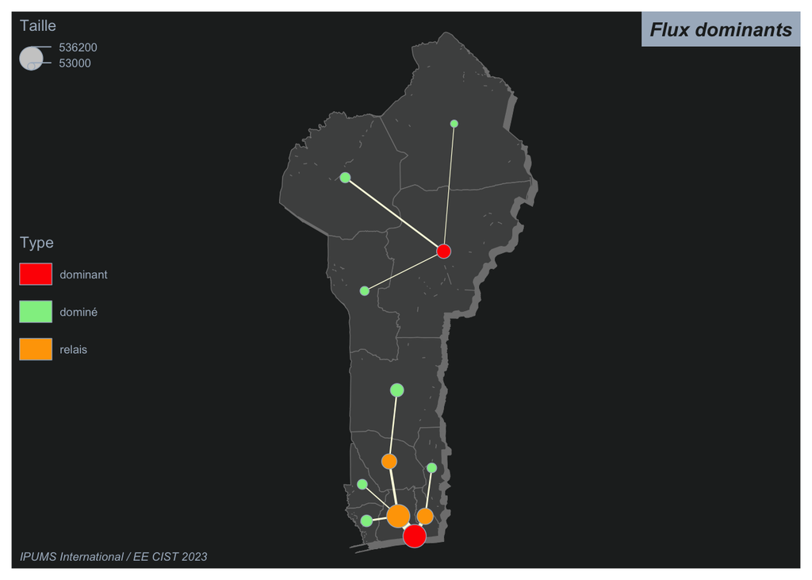